# Introduction to Git

AI Bootcamp

[figure not shown]

Mork Mongkul

## Table of Contents

1. What is Git?
2. Key Concepts
3. Setting Up Git
4. Cloning an Existing Repository
5. Git Branch
6. Reverting Changes
7. Using `.gitignore`
8. Additional Resources

# What is Git?

## What is Git?

- **Distributed version control system**
- Tracks changes in source code during software development
- Created by **Linus Torvalds** in **2005**
- Used for coordinating work among programmers, but can track changes in any set of files

## Key Concepts

| Term | Description |
| --- | --- |
| **Repository (Repo)** | A database storing all files and history of changes |
| **Commit** | A snapshot of the repository at a specific point in time |
| **Branch** | A separate line of development |
| **Merge** | Combining changes from different branches |
| **Clone** | Copying a repository to your local machine |
| **Push / Pull** | Syncing changes between local and remote repositories |

# Setting Up Git

## Setting Up Git

**Step 1 — Install Git:**

Download from https://git-scm.com/

**Step 2 — Configure your identity:**

```bash
git config --global user.name "Your Name"
git config --global user.email "your.email@example.com"
```

# Cloning an Existing Repository

## Creating a New Repository

**Navigate to your project directory:**

```bash
cd /path/to/your/project
```

**Initialize a new Git repository:**

```bash
git init
```

## Cloning an Existing Repository

**Clone a repository from a URL:**

```bash
git clone https://github.com/user/repo.git
```

> This creates a directory named `repo` containing all the files and history.

## Checking the Status

**Check the status of your files:**

```bash
git status
```

> This shows which files are **staged**, **unstaged**, or **untracked**.

## Adding Files to Staging Area

**Add a specific file / multiple files:**

```bash
git add filename
git add filename_1 filename_2
```

**Add all files:**

```bash
git add .
```

**Add all files of the same type:**

```bash
git add *.extension
```

## Renaming & Moving Files

**Rename a file:**

```bash
git mv old_filename new_filename
```

**Move a file to a different directory:**

```bash
git mv filename path/to/new_directory/
```

## Deleting Files

**Delete a file from the repository:**

```bash
git rm filename
```

**Forcefully remove a file:**

```bash
git rm -f filename
```

**Forcefully remove a directory and its contents:**

```bash
git rm -rf directoryname
```

> ⚠️ Use with caution — permanently deletes from your working directory and staging area.

## Committing Changes

**Commit staged changes with a message:**

```bash
git commit -m "Your commit message"
```

**Amend the last commit message:**

```bash
git commit --amend
```

## Viewing Commit History

**Full commit history:**

```bash
git log
```

> Shows a list of commits with their messages, authors, and dates.

**Compact one-line view:**

```bash
git log --oneline
```

# Git Branch

## Git Branch — Concept

A **branch** is a separate line of development.

- Work on features or fixes in isolation
- Merge back into main when ready
- Multiple developers can work simultaneously

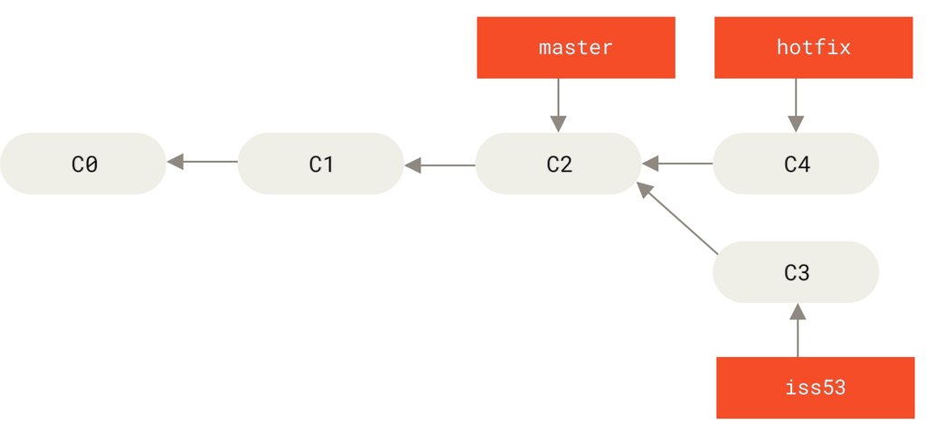

## Branching

**Create and switch to a new branch:**

```bash
git checkout -b new-branch
```

**Switch to an existing branch:**

```bash
git checkout existing-branch
```

**Modern alternative using `git switch`:**

```bash
git switch branch-name        # switch to existing
git switch -c new-branch-name # create and switch
```

## Merging Branches

**Merge a branch into the current branch:**

```bash
git merge branch-to-merge
```

> Resolve any conflicts that arise after merging.

## Deleting Branches

**Delete a branch locally:**

```bash
git branch -d branch-to-delete
```

**Delete a branch on the remote:**

```bash
git push origin --delete branch-to-delete
```

## Syncing with Remote Repository

**Push changes to remote:**

```bash
git push origin branch-name
```

**Pull changes from remote:**

```bash
git pull origin branch-name
```

## Swapping the Main Branch

```bash
# 1. Rename current main to old-main
git branch -m main old-main

# 2. Rename feature-branch to main
git branch -m feature-branch main

# 3. Update the remote
git push origin -u main

# 4. Delete old main from remote
git push origin --delete old-main
```

> If the main branch is protected, update the default branch in repository settings first.

# Resolving Conflicts

## Resolving Conflicts

- Occur when **changes in different branches are incompatible**
- Git **marks the conflicts** in the affected files
- Edit the files to resolve, then **add and commit** the changes

```bash
# After resolving conflicts:
git add resolved-file
git commit -m "Resolve merge conflict"
```

> Conflict markers look like:

```
<<<<<<< HEAD
your changes
=======
their changes
>>>>>>> branch
```

Edit the file, remove markers, keep what you need.

# Reverting Changes

## Reverting Changes

**Revert a specific file to a previous commit:**

```bash
git checkout commit-id -- filename
```

**Reset the entire repository to a previous commit:**

```bash
git reset --hard commit-id
```

**Safely undo a commit (creates new inverse commit):**

```bash
git revert commit-id
```

> `git revert` is preferred — it undoes changes **without altering** the commit history.

## Stashing Changes

**Stash current work-in-progress:**

```bash
git stash
git stash push -m "Your stash message"
```

**Apply / view / drop stashes:**

```bash
git stash list            # view all stashes
git stash apply           # apply latest stash
git stash apply stash@{1} # apply specific stash
git stash pop stash@{1}   # apply and remove
git stash drop            # remove latest stash
git stash clear           # remove all stashes
```

# Using `.gitignore`

## Using `.gitignore`

The `.gitignore` file tells Git which files or patterns to **ignore**.

**Common uses:**

- OS-generated files (`.DS_Store`, `Thumbs.db`)
- Log and temporary files
- Build artifacts and dependencies

**Generate for Python:**

```bash
curl -L -o .gitignore \
  https://www.toptal.com/developers/gitignore/api/python
```

**Example `.gitignore`:**

```
# Python
__pycache__/
*.pyc
*.pyo
.env
venv/

# Jupyter
.ipynb_checkpoints/

# OS
.DS_Store
Thumbs.db

# IDE
.vscode/
.idea/
```

## Getting Help & Common Problems

**Getting Help:**

```bash
git --help
git <command> --help

# Examples
git clone --help
git status --help
```

**Common Problems:**

| Problem | Fix |
| --- | --- |
| Merge conflict | Edit file → `git add` → `git commit` |
| Detached HEAD | `git checkout branch-name` |
| Forgotten file | `git add file` → `git commit --amend` |

## Tips & Team Workflow

**Best Practices:**

- Write **meaningful** commit messages
- Commit often with **small, incremental** changes
- Use **branches** to isolate features and fixes
- **Pull regularly** to stay in sync
- **Rebase** before merging for a clean history
- **Communicate** with teammates about changes

**Typical Team Push Flow:**

```bash
git status
git add filename
git commit -m "Your message"
git pull
# resolve conflicts if needed
git add filename
git commit -m "Resolve conflict"
git push
```

## Full Team Workflow Example

```bash
# 1. Clone the repository
git clone https://github.com/user/repo.git

# 2. Create a feature branch
git switch -c feature-branch

# 3. Make changes and commit
git add .
git commit -m "Add new feature"

# 4. Push branch to remote
git push origin feature-branch

# 5. Open a Pull Request on GitHub → review → merge

# 6. Update your local main
git switch main
git pull origin main
```

## Additional Resources

| Resource | Link |
| --- | --- |
| 📘 **Git Guide Book** | [git-scm.com/book](https://git-scm.com/book/en/v2) |
| 🌿 **Learning Branching** | [learngitbranching.js.org](https://learngitbranching.js.org/) |
| 🔷 **Atlassian Git Tutorials** | [atlassian.com/git](https://www.atlassian.com/git/tutorials) |
| 🏫 **W3Schools Git** | [w3schools.com/git](https://www.w3schools.com/git/) |

## Exercise 1 — Your First Repository

**Tasks:**

1. Configure Git with your name and email
2. Create a folder `my-first-repo` and initialize Git inside it
3. Create a `README.md` describing the project
4. Stage and commit with message `"Initial commit"`
5. Create a repo on GitHub and push your local repo to it

```bash
git config --global user.name "Your Name"
git config --global user.email "you@email.com"

mkdir my-first-repo && cd my-first-repo
git init

echo "# My First Repo" > README.md
git add README.md
git commit -m "Initial commit"

git remote add origin https://github.com/yourname/my-first-repo.git
git push -u origin main
```

## Exercise 2 — Branching & Merging

**Tasks:**

1. Inside `my-first-repo`, create a new branch called `feature/add-info`
2. Add a new file `info.txt` with any content and commit it
3. Switch back to `main`
4. Merge `feature/add-info` into `main`
5. Delete the feature branch after merging
6. Push the updated `main` to GitHub

```bash
git switch -c feature/add-info

echo "Some info about me" > info.txt
git add info.txt
git commit -m "Add info.txt"

git switch main
git merge feature/add-info

git branch -d feature/add-info

git push origin main
```

## Questions?

Instinct Institute

**Mork Mongkul**